# Why refit when you can retrieve?

Introducing liblex, an algorithmic framework for local model retrieval in infrared spectroscopy  
Nirpy Webminars

Leonardo Ramirez-Lopez

2026-11-03

## Localised modelling: why?

- Global linear models assume a single spectrum–response relationship: heterogeneous libraries may violate this.
- Local modelling (*a.k.a* memory-based learning) restricts fitting to spectrally similar samples, reducing the impact of domain shift (Næs et al., 1990; Shenk et al., 1997)

> *All models are wrong, but some are useful* – (Box, 1976)

## Localised modelling

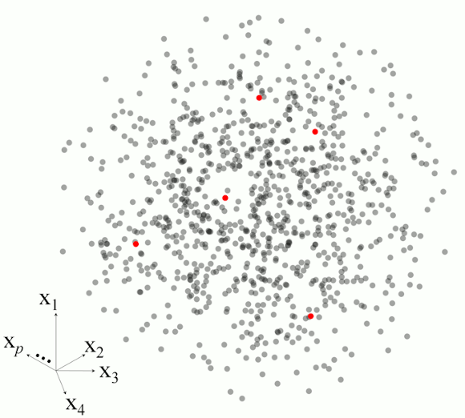

## Localised modelling: Trade-offs…

- Per-query refitting → computational cost at prediction time
- Full-library access required at prediction → data-sharing constraints
- No general-purpose interpretation across query-specific models
- Sensitivity to neighbour selection and spectral inconsistencies

# Why refit when you can retrieve?

*Our proposal …*

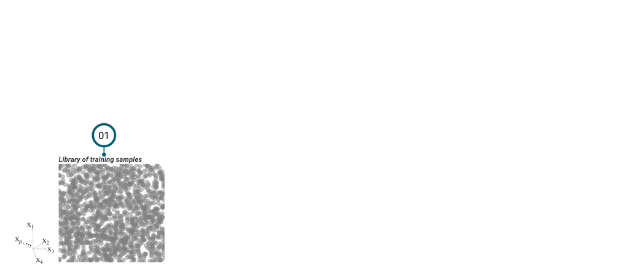

$$\mathcal{D}_r := \{(\mathbf{x}_r^j, y_r^j)\}_{j=1}^n$$

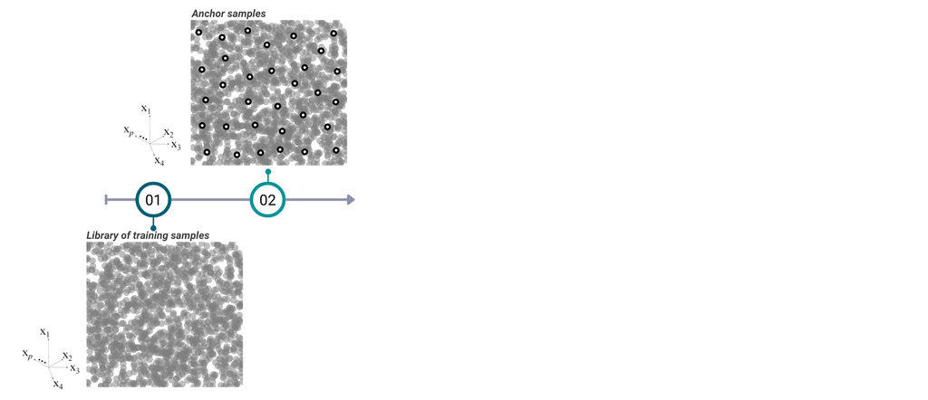

$$\mathcal{A} \subseteq \{1, \dots, n\}$$

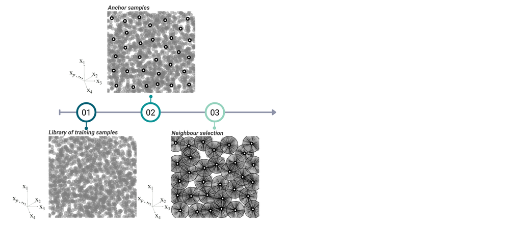

$$\mathcal{N}_k(a) = \{a\} \cup \mathrm{NN}_{k-1}(a), \quad |\mathcal{N}_k(a)| = k$$

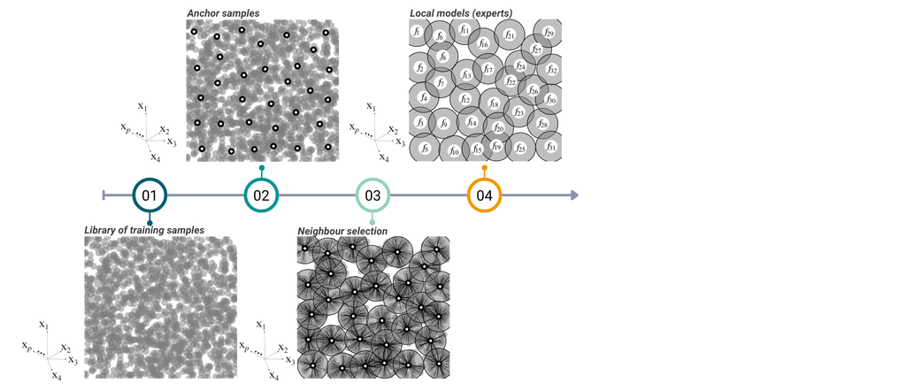

$$f_a: \mathbb{R}^d \to \mathbb{R}, \quad \mathbf{c}_a = \frac{1}{k}\sum_{j \in \mathcal{N}_k(a)} \mathbf{x}_r^j$$

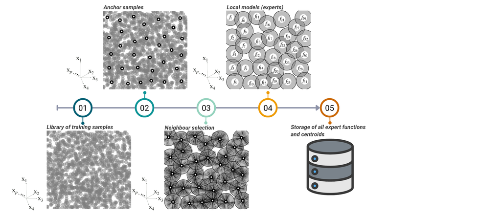

$$\mathcal{L} := \{(f_a, \mathbf{c}_a)\}_{a \in \mathcal{A}}$$

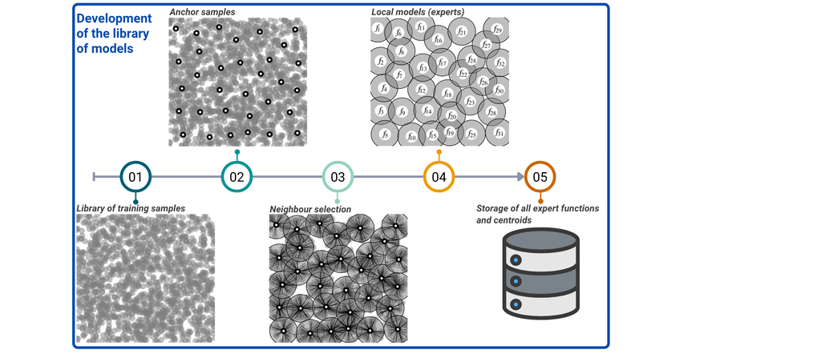

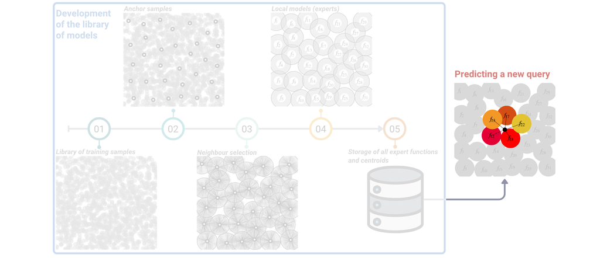

$\hat{y}(\mathbf{x}) = \sum_{a \in \mathcal{H}(\mathbf{x})} w_a(\mathbf{x})\, f_a(\mathbf{x}) \text{; } \rightarrow \mathcal{H}(\mathbf{x}) \text{: the }h \text{ nearest experts by centroid dissimilarity}$

## `liblex`

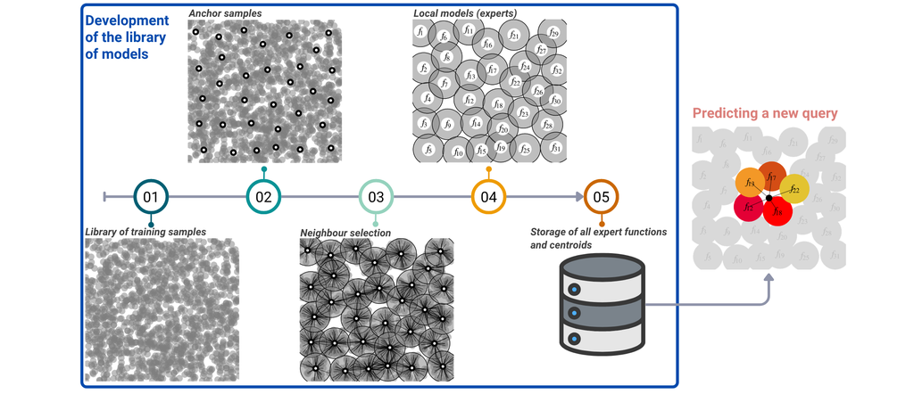

Library of local experts

## Operationalisation

- No per-query model refitting
- Deployment without access to the full reference library, preserving privacy
- Interpretable local models
- Intrinsic per-sample uncertainty proxy
- Anchor spectra or samples with missing $y$ values
- Incrementally extensible
- Competitive predictive accuracy
- Robust under severe domain shift?

## Background

Ramirez-Lopez et al. (2026)

[interactive chart not shown]

# An experiment in soils with mid IR data…

## Experiment [1/2]…

A **soil** IR spectral library from the North America (Hengl et al., 2021)

Open source

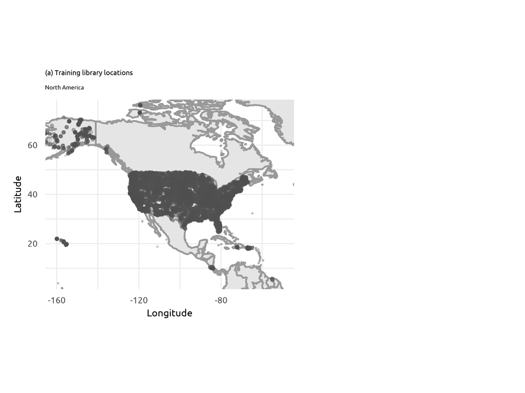

## Experiment [2/2]…

A **soil** IR spectral dataset from our target domain (Summerauer et al., 2021)

**Target** $y$: Total carbon

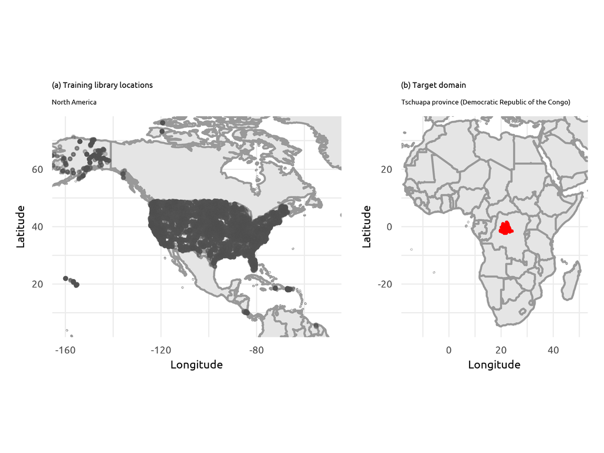

## Variable importance results [1/2]

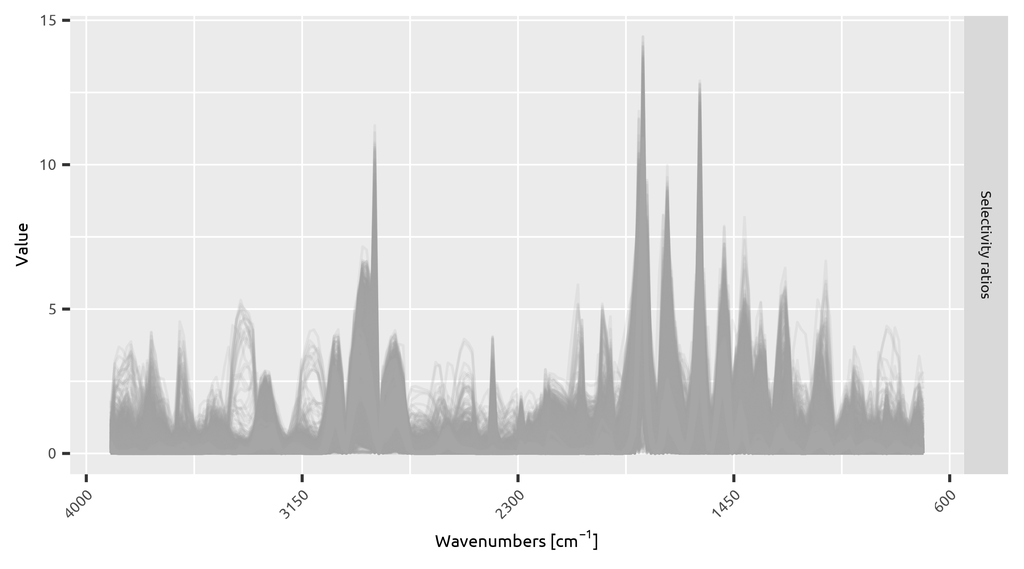

## Variable importance results [2/2]

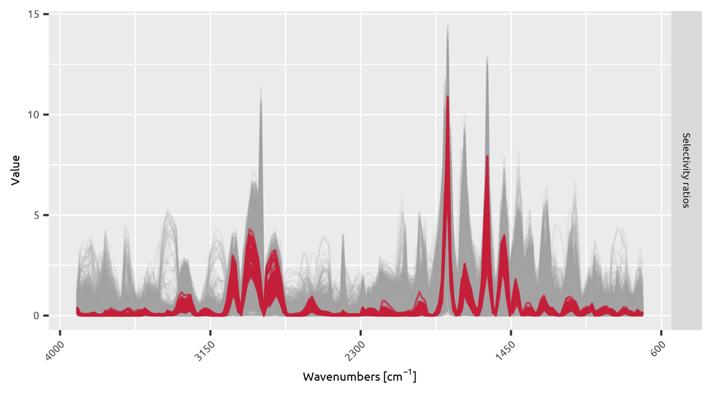

## Which anchors gave birth to our relevant experts?

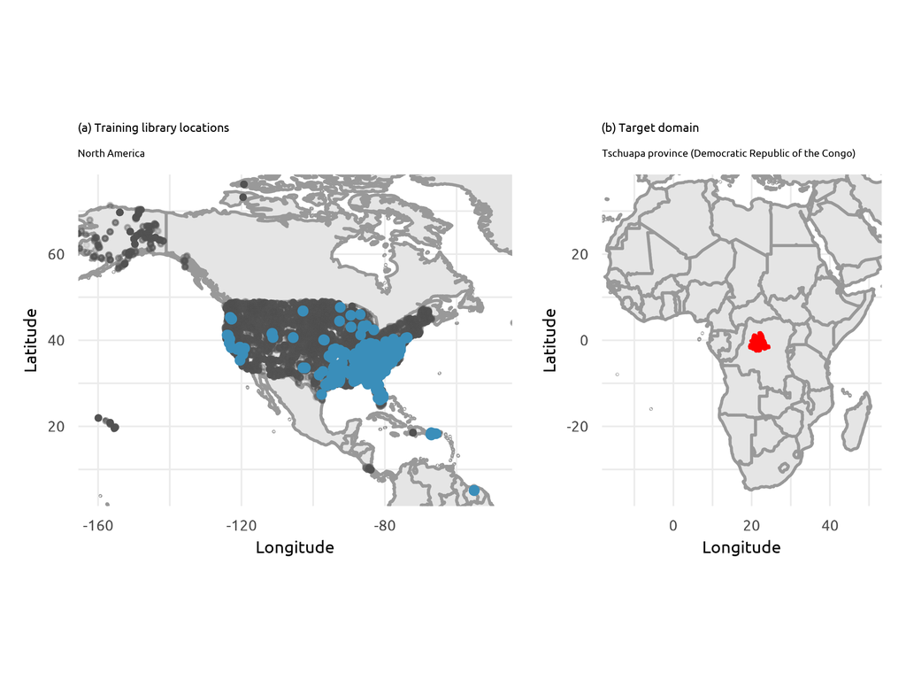

## Validation with independent samples…

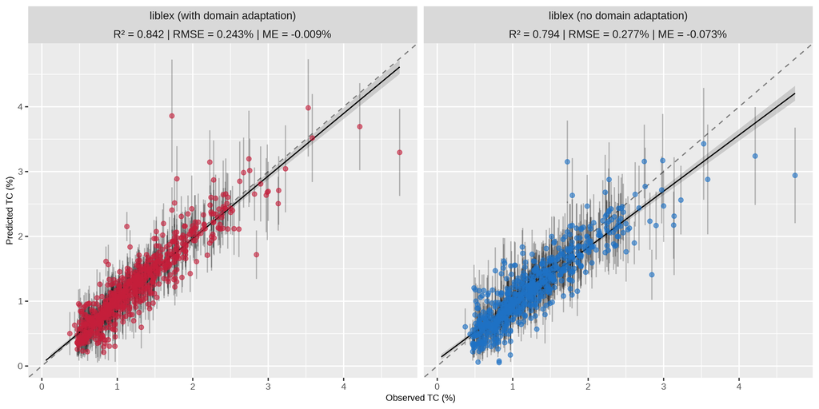

# Other tests in in soils with NIR data…

## Two kaggle competitions

[figure not shown]

[AfSIS soil properties](https://www.kaggle.com/competitions/afsis-soil-properties/code)

[Pedometrics 2026](https://www.kaggle.com/competitions/pedometrics2026/code)

# In a food and feed NIR applications…

## Feed

- Library built from data of 17 instruments/users: 4,747 local models
- Applied to one independent instrument/user, not represented in the library

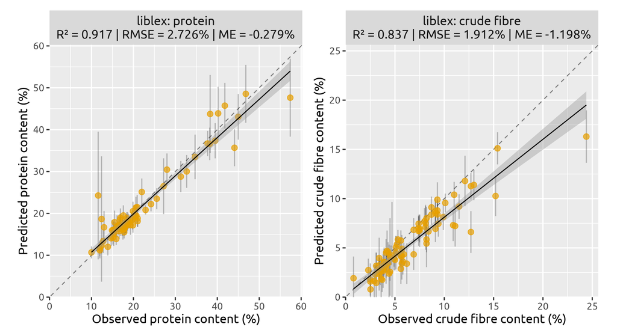

## Processed meat

- Library built from data of 42 instruments/users: 23,958 local models
- Applied to one independent instrument/user, not represented in the library

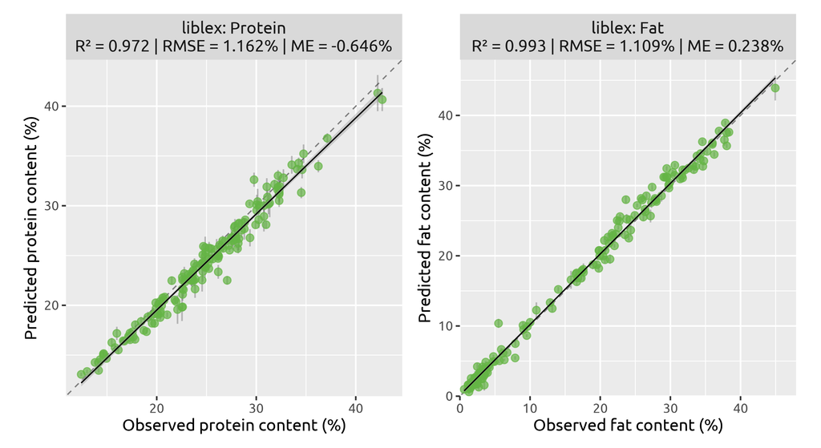

## Cheese

- Library built from data of 16 instruments/users: 6,518 local models
- Applied to one independent instrument/user, not represented in the library

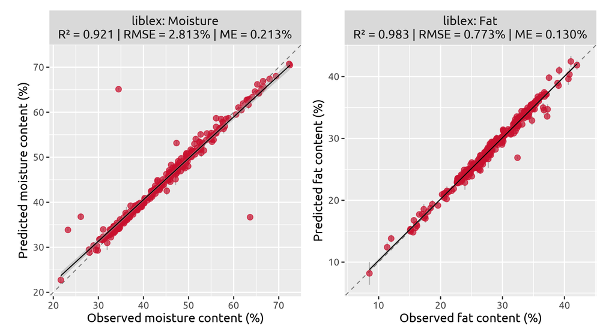

# How do I play with liblex???

## Open-source implementation…

[since 2013]

https://cran.r-project.org/package=resemble

```r
liblex()
```

## Open-source implementation…

[since 2013]

https://cran.r-project.org/package=resemble

and **matlab** version of `liblex` prepared by **Erik Andries**

## Future work

- Learned gating (stacking / meta-learner) as an alternative to distance-based weights
- Alternative dissimilarities (metric learning, embeddings)
- Incremental update policies and expert pruning
- Non-linear or hybrid expert architectures

## Our contributions

- Reformulate MBL: retrieval and aggregation of pre-computed local experts, replacing per-query refitting
- Retrieval-gated ensembling via centroid dissimilarity, decoupling neighbourhood definition from model centring
- Intrinsic per-sample uncertainty proxy from expert dispersion
- Deployment without full-library access, supporting privacy-preserving collaboration

# Peace

This presentation:

[figure not shown]

**📢 WORKSHOP ANNOUNCEMENT!**

*Applied NIR spectroscopy: from theory to calibration and instrumentation*

Join us at North Carolina State University (NCSU), Raleigh, NC, from 9$^{th}$ to 11$^{th}$ November 2026!

*Organisers*: Miguel Castillo (NCSU), Juan José Acosta (Camcore), Marçal Plans (BÜCHI) and Leonardo Ramirez-Lopez (BÜCHI)

This presentation:

[figure not shown]

## References

Box, G.E., 1976. Science and statistics. Journal of the American Statistical Association 71, 791–799.

Hengl, T., Sanderman, J., Parente, L., 2021. Open soil spectral library: Training data and calibration models. https://doi.org/10.5281/zenodo.5759694

Næs, T., Isaksson, T., Kowalski, B.R., 1990. Locally weighted regression and scatter correction for near-infrared reflectance data. Analytical Chemistry 62, 664–673.

Ramirez-Lopez, L., Rossel, R.V., Orellano, C., Kooijman, L., Perez-Fernandez, E., Wadoux, A.M.-C., Plans, M., Breure, T., Summerauer, L., Safanelli, J.L., others, 2026. When spectral libraries are too complex to search: Evolutionary subset selection for domain-adaptive calibration. Analytica Chimica Acta 345651. https://doi.org/10.1016/j.aca.2026.345651

Shenk, J.S., Westerhaus, M.O., Berzaghi, P., 1997. Investigation of a local calibration procedure for near infrared instruments. Journal of Near Infrared Spectroscopy 5, 223–232.

Summerauer, L., Baumann, P., Ramirez-Lopez, L., Barthel, M., Bauters, M., Bukombe, B., Reichenbach, M., Boeckx, P., Kearsley, E., Van Oost, K., others, 2021. The central african soil spectral library: A new soil infrared repository and a geographical prediction analysis. SOIL 7, 693–715.